# Mantis Shrimp

## Required Packages

- dplyr was used to manipulate the data
- ggplo2 was used to create figures
- tidyr was not used since the data was already arranged to desired standards

```r
library(dplyr)
library(ggplot2)
```

## Data used

```r
data_1 <- read.csv("https://ndownloader.figshare.com/files/16851587")
knitr::kable(data_1)
```

| species | appendage | mass | cor.telson | spring.telson | deformation.telson | impulse.telson | duration.telson | cor.abdomen | spring.abdomen | deformation.abdomen | impulse.abdomen | duration.abdomen |
| --- | --- | --- | --- | --- | --- | --- | --- | --- | --- | --- | --- | --- |
| falcatus | smasher | 0.24 | 0.51 | 22672 | 0.22030 | 0.00259 | 0.000667 | 0.9296000 | 13946.7283 | 0.3354 | 0.00256 | 0.000850 |
| falcatus | smasher | 0.93 | 0.60 | 46270 | 0.08440 | 0.00271 | 0.000467 | 0.3561000 | 13415.4735 | 0.2578 | 0.00258 | 0.000867 |
| falcatus | smasher | 0.30 | 0.67 | 90689 | 0.21530 | 0.00218 | 0.000333 | 0.5556000 | 62978.1950 | 0.3262 | 0.00183 | 0.000400 |
| falcatus | smasher | 1.12 | 0.63 | 43735 | 0.13930 | 0.00310 | 0.000480 | 0.5953000 | 17143.4028 | 0.2985 | 0.00202 | 0.000767 |
| falcatus | smasher | 1.20 | 0.71 | 84745 | 0.10770 | 0.00266 | 0.000345 | 0.5980000 | 22672.1502 | 0.1292 | 0.00231 | 0.000667 |
| espinosus | smasher | 0.33 | 0.62 | 15166 | 0.04850 | 0.00264 | 0.000824 | 0.7121000 | 9587.2723 | 0.2794 | 0.00279 | 0.001050 |
| espinosus | smasher | 0.41 | 0.59 | 41434 | 0.03550 | 0.00262 | 0.000500 | 0.6273000 | 26217.5893 | 0.4498 | 0.00262 | 0.000622 |
| espinosus | smasher | 0.30 | 0.58 | 43297 | 0.02480 | 0.00255 | 0.000494 | 0.5381000 | 9254.4442 | 0.4340 | 0.00250 | 0.001050 |
| espinosus | smasher | 0.24 | 0.69 | 74062 | 0.04130 | 0.00283 | 0.000373 | 0.6393000 | 17559.9265 | 0.2748 | 0.00268 | 0.000800 |
| espinosus | smasher | 0.32 | 0.64 | 59066 | 0.00458 | 0.00271 | 0.000420 | 0.7109000 | 32260.4019 | 0.2538 | 0.00282 | 0.000567 |
| chiragra | smasher | 3.02 | 0.29 | 31980 | 0.13060 | 0.00205 | 0.000642 | 0.3468000 | 10753.8712 | 0.2976 | 0.00213 | 0.001010 |
| chiragra | smasher | 4.10 | 0.32 | 61286 | 0.12720 | 0.00211 | 0.000447 | 0.4174000 | 22117.7223 | 0.1802 | 0.00224 | 0.000680 |
| chiragra | smasher | 2.98 | 0.55 | 44776 | 0.03600 | 0.00242 | 0.000487 | 0.5623000 | 32451.2644 | 0.0306 | 0.00253 | 0.000560 |
| chiragra | smasher | 3.47 | 0.46 | 174764 | 0.10180 | 0.00276 | 0.000247 | 0.6167000 | 28945.4782 | 0.2550 | 0.00260 | 0.000593 |
| chiragra | smasher | 3.93 | 0.55 | 51869 | 0.11900 | 0.00248 | 0.000447 | 0.2916000 | 21421.4634 | 0.1996 | 0.00208 | 0.000747 |
| chiragra | smasher | 4.71 | 0.55 | 120822 | 0.07330 | 0.00249 | 0.000320 | 0.7286000 | 41340.3945 | 0.1006 | 0.00275 | 0.000497 |
| chiragra | smasher | 5.93 | 0.50 | 22112 | 0.21740 | 0.00239 | 0.000689 | 0.4176000 | 14175.7815 | 0.3256 | 0.00225 | 0.000853 |
| smithii | smasher | 5.36 | 0.52 | 61509 | 0.16660 | 0.00240 | 0.000618 | 0.4490000 | 30262.4151 | 0.2236 | 0.00229 | 0.000593 |
| smithii | smasher | 5.42 | 0.51 | 63510 | 0.15620 | 0.00236 | 0.000440 | 0.4827000 | 52953.0946 | 0.1562 | 0.00237 | 0.000440 |
| smithii | smasher | 6.15 | 0.47 | 66507 | 0.12220 | 0.00235 | 0.000404 | 0.5141000 | 37387.8488 | 0.1742 | 0.00238 | 0.000526 |
| smithii | smasher | 4.78 | 0.54 | 113802 | 0.08540 | 0.00238 | 0.000320 | 0.5298000 | 33535.7103 | 0.1882 | 0.00239 | 0.000553 |
| smithii | smasher | 3.89 | 0.65 | 82375 | 0.10040 | 0.00264 | 0.000353 | 0.6521000 | 44687.2065 | 0.2066 | 0.00258 | 0.000480 |
| bredeni | smasher | 1.29 | 0.63 | 90780 | 0.09860 | 0.00265 | 0.000261 | 0.6712684 | 18431.4040 | 0.3206 | 0.00264 | 0.000739 |
| bredeni | smasher | 0.52 | 0.45 | 40306 | 0.25520 | 0.00233 | 0.000500 | 0.4985725 | 8548.2869 | 0.4095 | 0.00243 | 0.000800 |
| bredeni | smasher | 0.54 | 0.54 | 22672 | 0.09990 | 0.00196 | 0.000667 | 0.6583551 | 14130.8415 | 0.1237 | 0.00210 | 0.000844 |
| bredeni | smasher | 1.09 | 0.45 | 22977 | 0.00000 | 0.00221 | 0.000662 | 0.5562426 | 11753.2427 | 0.0220 | 0.00228 | 0.000926 |
| bredeni | smasher | 0.59 | 0.62 | 46270 | 0.22120 | 0.00225 | 0.000467 | 0.4139881 | 1453.1101 | 0.8662 | 0.00211 | 0.002630 |
| festae | smasher | 0.99 | 0.56 | 26214 | 0.25320 | 0.00251 | 0.000620 | 0.6638000 | 10636.2123 | 0.4390 | 0.00271 | 0.000973 |
| festae | smasher | 0.50 | 0.57 | 44660 | 0.19440 | 0.00217 | 0.000475 | 0.6111000 | 13012.0238 | 0.3833 | 0.00233 | 0.000880 |
| festae | smasher | 1.03 | 0.33 | 12440 | 0.06520 | 0.00193 | 0.000900 | 0.3459000 | 5861.8027 | 0.0791 | 0.00232 | 0.001310 |

[output cut: 60 more lines]

## What does this data describe? (Prose)

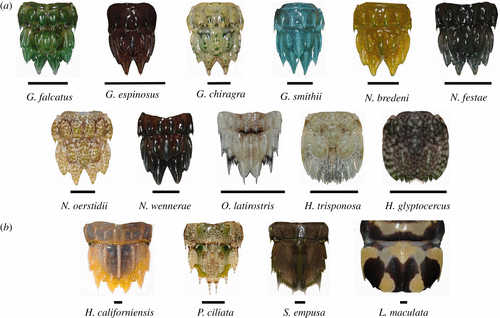

Mantis Shrimp Shells

- Many types of animals develop morphological traits to partake in ritualized combat.
- Mantis shrimp present an interesting case in which their unique form of ritualized combat, termed telson sparring, may have coevolved with specialized morphological armour.

## Data Manipulation

- I mutated data_1 to add a new column of the ratio between the telson COR and abdomen COR
- lower ratio = telson and abdomen COR difference smaller
- higher ratio = telson and abdomen COR differece larger (telson COR is greater)
- I then separated the data into a "small" and "big" category by filtering the mass of the shrimp. This was done to create figures with clearer axis.

```r
data_1_modified <- mutate(data_1, ratio = (cor.telson/cor.abdomen))
big_shrimps <- data_1_modified %>%
  group_by(species) %>%
  filter(mass > 15)
small_shrimps <- data_1_modified %>%
  group_by(species) %>%
  filter(mass < 15)
```

## Figures

The figures created use mass on the x axis and the ratio of COR between the telson and the abdomen.

Geom_point and geom_smooth are used to create points and a trend line, the axis are then scaled to the minimum and maximum mass and ratio values for the small and big categories.

Then, facet_wrap is used to seaparate the graphs by species.

The purpose of this manipulation was to determine if there was a relationship between mass and ratio of COR telson vs abdomen across different species of mantis shrimp.

## Figure 1

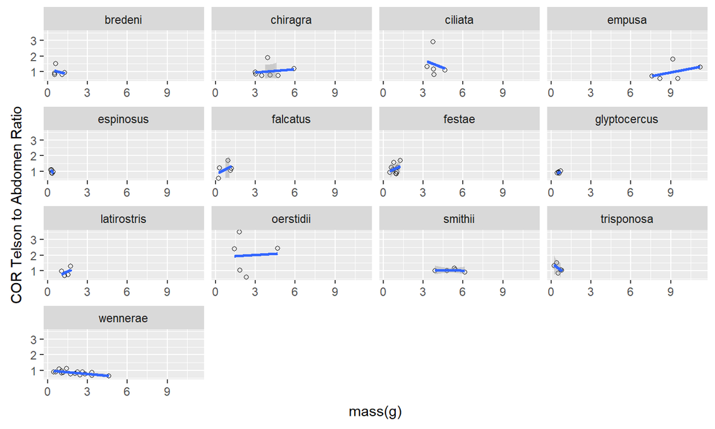

## Figure 2

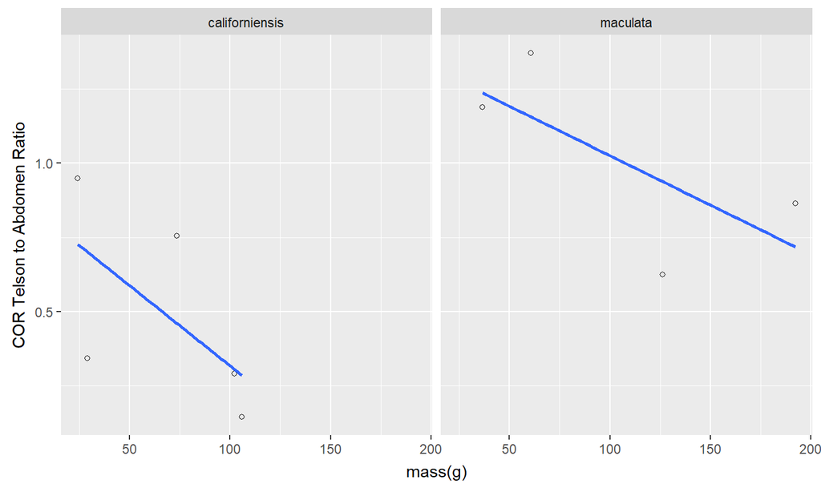